# Was Superbowl 52 an outlier or has the NFL become more offensive?

#### Sahil Mariwala, Shane Cray

The superbowl last year, Superbowl 52, was memorable for several reasons. It was Tom Brady's eighth superbowl appearance and resulted in the Philidelphia Eagles receiving their first superbowl victory. In addition, it shattered the record for most combined yardage in a superbowl. The final total was 1,151, breaking the previous record by 200 yards. The ball was punted only once in a game that showcased two very dominant offenses. This superbowl raises a lot of questions. Are NFL teams doing better on offense or was this game an outlier? If NFL teams are doing better on offense, what strategies are they employing? Are they passing more or rushing more? Should we expect to see more offensive yards in playoff games?

In this tutorial, we will be using three different datasets which include QB statistics, Total NFL season game averages, and QB passing yard leaders from 1996 to 2016. Further reading about football data can be done at [pro football reference](https://www.pro-football-reference.com) and for the ability to craft more detailed queries.

## The basics

The libraries we will be using are [pandas](https://pandas.pydata.org/pandas-docs/stable/), [numpy](https://docs.scipy.org/doc/numpy/user/), [scikit-learn](http://scikit-learn.org/stable/documentation.html), and [matplotlib](https://matplotlib.org/contents.html).

```python
import pandas as pd
import numpy as np
from sklearn import linear_model
import matplotlib.pyplot as plt
```

The first dataset we will be using a csv file containing several important QB metrics between 1996 and 2016. Lets read the data in and use ',' as our separator because we know the file uses commas to separate the data.

```python
data = pd.read_csv("QBStats_all.csv", sep=',')
data.head()
```

|  | qb | att | cmp | yds | ypa | td | int | lg | sack | loss | rate | game_points | home_away | year |
| --- | --- | --- | --- | --- | --- | --- | --- | --- | --- | --- | --- | --- | --- | --- |
| 0 | Boomer EsiasonB. Esiason | 38 | 25 | 237.0 | 6.2 | 0 | 0 | 20 | 2.0 | 11.0 | 82.9 | 13 | away | 1996 |
| 1 | Jim HarbaughJ. Harbaugh | 25 | 16 | 196.0 | 7.8 | 2 | 1 | 35t | 0.0 | 0.0 | 98.1 | 20 | home | 1996 |
| 2 | Paul JustinP. Justin | 8 | 5 | 53.0 | 6.6 | 0 | 0 | 30 | 1.0 | 11.0 | 81.8 | 20 | home | 1996 |
| 3 | Jeff GeorgeJ. George | 35 | 16 | 215.0 | 6.1 | 0 | 0 | 55 | 7.0 | 53.0 | 65.8 | 6 | away | 1996 |
| 4 | Kerry CollinsK. Collins | 31 | 17 | 198.0 | 6.4 | 2 | 0 | 30 | 4.0 | 12.0 | 95.9 | 29 | home | 1996 |

There are some good stats in here! However, we are mostly interested in the numerical values. Lets ignore the Quarterback names and whether they were home or away and group these stats by year and perhaps look at the averages from year to year.

```python
df = data.groupby('year')
X = np.array(list(df.groups.keys()))[:,np.newaxis]
df = df.mean()
df
```

| year | att | cmp | yds | ypa | td | sack | loss | rate | game_points |
| --- | --- | --- | --- | --- | --- | --- | --- | --- | --- |
| 1996 | 25.589372 | 14.737520 | 170.988728 | 6.593881 | 1.004831 | 1.777778 | 11.402576 | 76.064734 | 20.270531 |
| 1997 | 25.206731 | 14.173077 | 168.730769 | 6.740705 | 0.988782 | 2.006410 | 13.482372 | 75.995513 | 20.056090 |
| 1998 | 24.126168 | 13.654206 | 165.242991 | 6.768536 | 1.024922 | 1.880062 | 11.996885 | 76.654829 | 21.309969 |
| 1999 | 25.824345 | 14.741140 | 174.505393 | 6.553775 | 1.024653 | 1.924499 | 12.272727 | 74.914176 | 20.443760 |
| 2000 | 25.365625 | 14.756250 | 171.282813 | 6.820625 | 0.984375 | 1.917188 | 11.682813 | 75.990000 | 20.490625 |
| 2001 | 26.389525 | 15.577741 | 178.991817 | 7.132079 | 1.039280 | 1.945990 | 12.301146 | 78.292799 | 20.121113 |
| 2002 | 26.616692 | 15.873261 | 178.814529 | 6.621329 | 1.071097 | 1.811437 | 11.616692 | 78.102628 | 21.292117 |
| 2003 | 24.610860 | 14.447964 | 163.153846 | 6.594419 | 0.974359 | 1.622926 | 10.185520 | 75.659427 | 20.601810 |
| 2004 | 25.237654 | 15.080247 | 177.990741 | 6.776698 | 1.129630 | 1.845679 | 11.637346 | 79.322068 | 21.291667 |
| 2005 | 25.846154 | 15.368917 | 175.386185 | 6.831554 | 1.010989 | 1.855573 | 11.857143 | 79.153375 | 20.555730 |
| 2006 | 26.433871 | 15.800000 | 181.091935 | 6.714032 | 1.045161 | 1.875806 | 11.956452 | 78.647419 | 20.541935 |
| 2007 | 26.453834 | 16.175274 | 181.463224 | 6.750235 | 1.118936 | 1.715180 | 11.125196 | 80.018936 | 21.571205 |
| 2008 | 26.399361 | 16.103834 | 183.332268 | 7.032588 | 1.031949 | 1.654952 | 10.525559 | 81.843291 | 21.400958 |
| 2009 | 25.459016 | 15.903130 | 176.599001 | 6.793741 | 1.059613 | 1.683486 | 10.804281 | 79.664526 | 21.312966 |
| 2010 | 27.630400 | 16.785600 | 193.513600 | 6.759040 | 1.201600 | 1.808000 | 12.022400 | 81.981920 | 21.852800 |
| 2011 | 28.355049 | 17.042345 | 204.120521 | 7.194137 | 1.213355 | 1.934853 | 12.587948 | 81.983062 | 22.298046 |
| 2012 | 29.450331 | 17.935430 | 208.528146 | 7.144868 | 1.253311 | 1.935430 | 12.471854 | 84.692550 | 22.655629 |
| 2013 | 30.565365 | 18.714771 | 217.704584 | 7.191681 | 1.351443 | 2.190153 | 14.449915 | 84.959762 | 23.349745 |
| 2014 | 29.024351 | 18.181818 | 209.250000 | 7.308279 | 1.310065 | 1.967532 | 12.420455 | 87.311039 | 22.465909 |
| 2015 | 30.908784 | 19.471284 | 224.136824 | 7.255912 | 1.422297 | 2.005068 | 13.265203 | 88.911149 | 22.547297 |
| 2016 | 29.895082 | 18.836066 | 213.921311 | 7.086066 | 1.285246 | 1.824590 | 11.783607 | 86.853115 | 22.909836 |

Now this is interesting. After just giving the table a cursory glance, it really does look like QBs have been improving. In 1996 the average QB passed for around 170 yards per game. That number is now around 215! I'm going to create a scatter plot for these stats and add a linear trend line to understand the significance of this data.

```
Text(0,0.5,'Completion percentage')
```

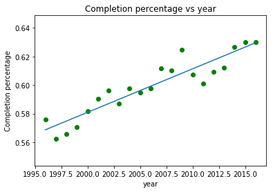

```python
lm = linear_model.LinearRegression()
Y = df['cmp'].values / df['att'].values
lm.fit(X, Y)
pred = lm.predict(X)
plt.scatter(X, Y, color = 'g')
plt.plot(X, pred)
plt.title('Completion percentage vs year')
plt.xlabel('year')
plt.ylabel('Completion percentage')
```

Average QB completion percentages have gone from 57% to 63% in 20 years showing that quarterbacks are connecting more with their receivers.

```
Text(0,0.5,'Average yards per game')
```

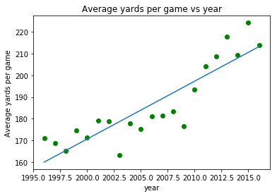

```python
Y = df['yds'].values
lm.fit(X, Y)
pred = lm.predict(X)
plt.scatter(X, Y, color = 'g')
plt.plot(X, pred)
plt.title('Average yards per game vs year')
plt.xlabel('year')
plt.ylabel('Average yards per game')
```

Along with those higher completion percenatages, QBs are passing for more yards. The difference has been about 45 yards more.

```
Text(0,0.5,'Average yards per attempt')
```

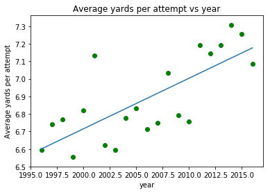

```python
Y = df['ypa'].values
lm.fit(X, Y)
pred = lm.predict(X)
plt.scatter(X, Y, color = 'g')
plt.plot(X, pred)
plt.title('Average yards per attempt vs year')
plt.xlabel('year')
plt.ylabel('Average yards per attempt')
```

In addition to connecting more with their receivers, they are also gaining more yardage on every play.

```
Text(0,0.5,'Average tds per game')
```

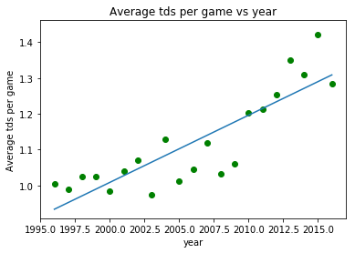

```python
Y = df['td'].values
lm.fit(X, Y)
pred = lm.predict(X)
plt.scatter(X, Y, color = 'g')
plt.plot(X, pred)
plt.title('Average tds per game vs year')
plt.xlabel('year')
plt.ylabel('Average tds per game')
```

And also scoring more touchdowns each game.

```
Text(0,0.5,'Average total points scored')
```

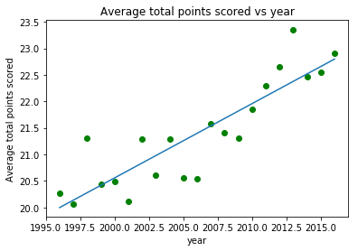

```python
Y = df['game_points'].values
lm.fit(X, Y)
pred = lm.predict(X)
plt.scatter(X, Y, color = 'g')
plt.plot(X, pred)
plt.title('Average total points scored vs year')
plt.xlabel('year')
plt.ylabel('Average total points scored')
```

This leads to more total points being scored each game.

```
Text(0,0.5,'QB Rating')
```

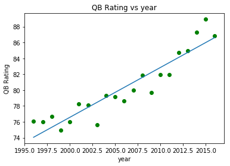

```python
Y = df['rate'].values
lm.fit(X, Y)
pred = lm.predict(X)
plt.scatter(X, Y, color = 'g')
plt.plot(X, pred)
plt.title('QB Rating vs year')
plt.xlabel('year')
plt.ylabel('QB Rating')
```

Overall, this can be summarized by the average quarterback rating steadily climbing in the past 20 years. However, there are 2 stats that did not change/have a correlation.

```
Text(0,0.5,'Average sacks per game')
```

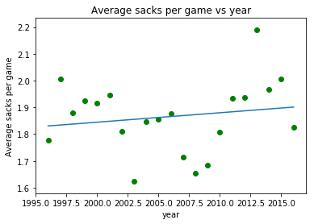

```python
Y = df['sack'].values
lm.fit(X, Y)
pred = lm.predict(X)
plt.scatter(X, Y, color = 'g')
plt.plot(X, pred)
plt.title('Average sacks per game vs year')
plt.xlabel('year')
plt.ylabel('Average sacks per game')
```

The average sacks in a game remained roughly the same which means QBs are getting sacked at roughly the same rate.

```
Text(0,0.5,'Average lost yards per game')
```

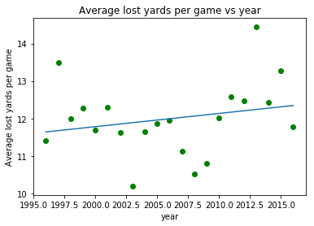

```python
Y = df['loss'].values
lm.fit(X, Y)
pred = lm.predict(X)
plt.scatter(X, Y, color = 'g')
plt.plot(X, pred)
plt.title('Average lost yards per game vs year')
plt.xlabel('year')
plt.ylabel('Average lost yards per game')
```

The lost yards attributed to the QB also stayed roughly the same.

After seeing that data, it's clear that quarterbacks are better in almost every metric. They are attempting more passes, completing more passes, gaining more yards and scoring more points. However, does this net gain for quarterbacks translate into a net gain everywhere in the offense? Are runningbacks running more yards and scoring more touchdowns? For this question, I looked on pro-football-reference.com for more information about the NFL offense during the same time frame.

```
Text(0,0.5,'Average rushing yards per game')
```

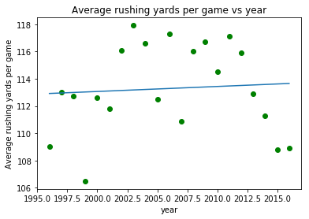

```python
df = pd.read_csv("nfl_offense_average.csv", sep=',')
df = df[df['Year'] >= 1996]
df = df[df['Year'] <= 2016]
df = df[::-1]
Y = df['rY/G'].values
lm.fit(X, Y)
pred = lm.predict(X)
plt.scatter(X, Y, color = 'g')
plt.plot(X, pred)
plt.title('Average rushing yards per game vs year')
plt.xlabel('year')
plt.ylabel('Average rushing yards per game')
```

It looks like there has been no improvement in rushing yards per game in this time frame.

```
Text(0,0.5,'Average rushing td points')
```

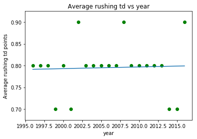

```python
Y = df['rTD'].values
lm.fit(X, Y)
pred = lm.predict(X)
plt.scatter(X, Y, color = 'g')
plt.plot(X, pred)
plt.title('Average rushing td vs year')
plt.xlabel('year')
plt.ylabel('Average rushing td points')
```

And there has been no improvement in the number of touchdowns scored in the same time frame as well. This suggests that teams continue to run the ball for roughly the same gain while passing more effectively. So while the NFL may be more offensive, the real gains can be attributed to QB performance. However, we looked how the average QB and how they have improved. Have the top QBs roughly improved around the same as the average QB or have they performed better? This is an important piece for determining whether teams that make the playoffs are becoming more offensive and will determine if we will see more offensive driven playoff games and superbowls

For this, I have scraped the top 10 QBs by passing yards for each year and appended it to a csv file.

```python
df = pd.read_csv("top_10_qbs.csv", sep=',')
df[['Player', 'Yds▼']].head()
```

|  | Player | Yds▼ |
| --- | --- | --- |
| 0 | Drew Brees*\BreeDr00 | 5208 |
| 1 | Matt Ryan*+\RyanMa00 | 4944 |
| 2 | Kirk Cousins*\CousKi00 | 4917 |
| 3 | Aaron Rodgers*\RodgAa00 | 4428 |
| 4 | Philip Rivers*\RivePh00 | 4386 |

The following code appends the top 10 to match the data from 1996-2016 and creates a plot

```
Text(0,0.5,'Average yards per attempt')
```

[figure not shown]

```python
arr = []
count = 0
sum = 0
for e in df['Yds▼']:
    if count<10:
        sum+=e
        count+=1
    else:
        arr.append(sum/10)
        count = 1
        sum = e
arr.append(sum/10)
Y = arr[::-1]
lm.fit(X, Y)
pred = lm.predict(X)
plt.scatter(X, Y, color = 'g')
plt.plot(X, pred)
plt.title('Average yards per attempt vs year')
plt.xlabel('year')
plt.ylabel('Average yards per attempt')
```